# PM 566 Midterm Project

Author

Uma Agarwal

# **Postoperative Sepsis Outcomes for Elective Surgeries in California Hospitals (2019-2023)**

**Introduction**

Postoperative sepsis, the immune system’s extreme response to infections following surgical procedures, is considered a potentially avoidable adverse complication. In order to evaluate the quality of care given by hospitals, the Department of Health Care Access and Information uses the Postoperative Sepsis indicator as one of the Patient Safety Indicators; evidence suggests that postoperative sepsis may be associated with deficiencies in the quality of care provided by hospitals.

Here, I obtained a dataset from California Health and Human Services which contains data on in-hospital postoperative sepsis cases following elective surgeries in California Hospitals from 2019-2023. I sought to understand how sepsis rates changed over time based on county category (urban vs rural). I focused on whether the county was “rural” (i.e. had few to no major hospitals) or urban (i.e. had several major hospitals). I also wanted to understand if the COVID-19 pandemic had any effect on both the number of elective surgeries performed, as well as the sepsis rates.

**Data Preparation**

This dataset was obtained from the California Health and Human Services data portal (https://data.chhs.ca.gov/). It contains 1470 observations (corresponding to individual hospitals) and 10 variables. The variables include the year, county, hospital OSHPDID (unique ID for each hospital), hospital name, total postoperative sepsis cases, total elective surgical discharges, latitude and longitude of the hospital, risk-adjusted postoperative sepsis rate, and risk-adjusted performance rating. The reported postoperative sepsis rates are risk-adjusted for patient age, gender, pre-existing health conditions, and surgery performed to account for the fact that the some patients have greater chances of developing sepsis over others. The reported performance rating uses the 95% confidence intervals for the risk-adjusted sepsis rates and grades the hospital as Below Average (lower CI is greater than the state rate), Average, or Above Average (lower CI is lower than state rate).

To prepare the data, I first noticed that there was an observation where County = “STATEWIDE”, which appeared to represent overall statistics for the whole state for each year. Since I intended to focus only on individual counties, I filtered these observations from the data. I also noticed that the Latitude and Longitude variables were non-numeric; I wanted to use these as numeric variables downstream, so I converted them to numeric. Additionally, I factored the Risk-adjusted performance rates to assign numeric values to the categories (Below Average = 1, Above Average = 3) so that I compute the mean of this variable later on. I then created 2 summarized datasets containing the averaged Risk-adjusted Postoperative Sepsis Rates and the average Risk-adjusted Performance Ratings per county for each year. Finally, a I created one more summarized dataset containing the year, county, number of hospitals per county, and Risk-adjusted Performance Rating.

```r
library(tidyverse)
library(knitr)

# from CalHHS https://data.chhs.ca.gov/dataset/postoperative-sepsis-outcomes-for-elective-surgeries-in-california-hospitals
sepsis_rates <- read_csv("data/2019-2023-postoperative-sepsis-rates.csv")

# filter out STATEWIDE observation
sepsis_rates <- sepsis_rates %>%
  filter(County != "STATEWIDE")

# change lat and lon to numeric
sepsis_rates <- sepsis_rates %>%
  mutate(
    Latitude = as.numeric(Latitude),
    Longitude = as.numeric(Longitude)
  )

# assign numeric values to Performance Rating variable
sepsis_rates <- sepsis_rates %>%
  mutate(perf_rating.f = factor(`Risk-adjustedAveragePerformanceAverageRating`,
                                levels = c("Below Average",
                                           "Average",
                                           "Above Average"),
                                ordered = TRUE),
         perf_score = as.numeric(perf_rating.f))

# avg sepsis rates per county by year
avg_sepsis_rates <- sepsis_rates %>%
  group_by(Year, County) %>%
  summarise(sepsis_avg = mean(`Risk-adjusted Postoperative Sepsis Rate`), .groups = "drop")

# avg performance rating per county by year
avg_ratings <- sepsis_rates %>%
  group_by(Year, County) %>%
  summarise(perf_rate_avg = mean(perf_score), .groups = "drop")

# joined avg rating & number of hospitals per county
counties <- sepsis_rates %>%
  count(Year, County) %>%
  left_join(avg_ratings, by = c("Year", "County"))
```

**Exploratory Analysis**

```r
# exploratory analysis
dim(sepsis_rates)
head(sepsis_rates)
tail(sepsis_rates)
str(sepsis_rates)
hist(sepsis_rates$`Postoperative Sepsis Cases`)
```

[output not shown]

```r
hist(sepsis_rates$`Elective Surgical Discharges`)
```

[output not shown]

```r
hist(sepsis_rates$`Risk-adjusted Postoperative Sepsis Rate`)
```

[output not shown]

```r
table(sepsis_rates$`Risk-adjustedAveragePerformanceAverageRating`)
summary(sepsis_rates)
```

**Preliminary Results**

To understand how sepsis rates change over time by county, I first looked at which counties had the most and fewest hospitals. I considered that counties with more major hospitals would likely be more urban and have a denser population, while counties with fewer major hospitals would likely have a sparser population and be more rural. I found that the counties with the most hospitals were Los Angeles, Orange, San Diego, Riverside, Alameda, and San Bernardino. These counties do have dense populations, so these results are as expected. I also found that the counties with the fewest hospitals were all tied for 1 hospital; these counties included Amador, Calavera, De Norte, Inyo, Kings, Lassen, Madera, Mono, Plumas, San Benito, Sutter, Tehama, Tuolumne, and Yuba. These counties are primarily from the Northern California and Eastern Sierra regions, which are often sparsely populated due to the mountainous terrain, so these results also make sense.

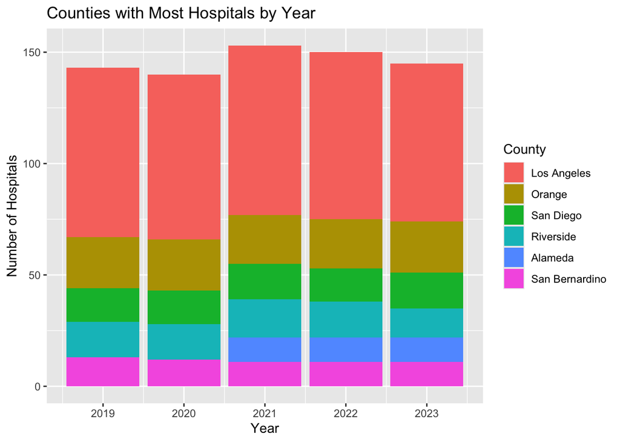

```r
# top 5 counties with most hospitals by year
top_hospitals <- sepsis_rates %>%
  count(Year, County) %>%
  group_by(Year) %>%
  slice_max(order_by = n, n = 5) %>%
  arrange(Year, desc(n))

# stacked barchart
top_hospitals %>%
  ggplot(aes(x = Year, y = n, fill = fct_reorder2(County, Year, n))) +
  geom_bar(stat = "identity", position = "stack") +
  labs(title = "Counties with Most Hospitals by Year",
       y = "Number of Hospitals",
       fill = "County")
```

```r
# bottom counties with fewest hospitals by year
# all tied for 1 hospital, no visualization
bottom_hospitals <- sepsis_rates %>%
  count(Year, County) %>%
  group_by(Year) %>%
  slice_min(order_by = n, n = 5) %>%
  arrange(Year, n)
```

I additionally wanted to examine whether the “rural” counties, in other words, the counties with fewer hospitals, had worse overall outcomes compared to the “urban” counties due to differences in resource access and availability. To explore this, I first averaged the Risk-adjusted Performance Ratings per county for each year, then selected the top 3 and bottom 3 counties. These counties are visualized in Table 1 and Table 2. Finally, I created five plots each representing a single year which shows the relationship between number of hospitals and average performance rating. In each plot, the smoothing spline appears relatively flat, even after removing the potentially influential point representing Los Angeles County at the far right of each plot (not shown), suggesting that whether a county is “rural” or “urban” does not have a significant effect on overall outcomes.

```r
# top 3 county avg perf ratings by year
top_ratings <- avg_ratings %>%
  group_by(Year) %>%
  slice_max(order_by = perf_rate_avg, n = 3) %>%
  arrange(Year, desc(perf_rate_avg))

top_ratings_table <- top_ratings %>%
  group_by(Year) %>%
  arrange(desc(perf_rate_avg), .by_group = TRUE) %>%
  mutate(Rank = factor(row_number(), labels = c("1st", "2nd", "3rd"))) %>%
  select(Year, Rank, County) %>%
  pivot_wider(
    names_from = Rank,
    values_from = County,
    names_glue = "{Rank} ({.value})"
  )
kable(top_ratings_table,
      caption = "Table 1: Top 3 Counties by Average Performance Rating Each Year")
```

Table 1: Top 3 Counties by Average Performance Rating Each Year

| Year | 1st (County) | 2nd (County) | 3rd (County) |
| --- | --- | --- | --- |
| 2019 | San Mateo | Sacramento | Santa Barbara |
| 2020 | Santa Clara | Sacramento | San Mateo |
| 2021 | San Mateo | San Bernardino | San Francisco |
| 2022 | Sacramento | San Francisco | San Bernardino |
| 2023 | Sacramento | Alameda | San Bernardino |

```r
# bottom 3 county avg perf ratings by year
bottom_ratings_table <- avg_ratings %>%
  group_by(Year) %>%
  slice_min(order_by = perf_rate_avg, n = 3, with_ties = FALSE) %>%
  arrange(perf_rate_avg, .by_group = TRUE) %>%
  mutate(Rank = factor(row_number(), labels = c("58th", "57th", "56th"))) %>%
  select(Year, Rank, County) %>%
  pivot_wider(
    names_from = Rank,
    values_from = County,
    names_glue = "{Rank} ({.value})"
  )
kable(bottom_ratings_table,
      caption = "Table 2: Bottom 3 Counties by Average Performance Rating Each Year")
```

Table 2: Bottom 3 Counties by Average Performance Rating Each Year

| Year | 58th (County) | 57th (County) | 56th (County) |
| --- | --- | --- | --- |
| 2019 | Lake | Solano | San Francisco |
| 2020 | Santa Cruz | Stanislaus | San Joaquin |
| 2021 | Butte | Imperial | Monterey |
| 2022 | Santa Cruz | Solano | San Diego |
| 2023 | Del Norte | Imperial | Nevada |

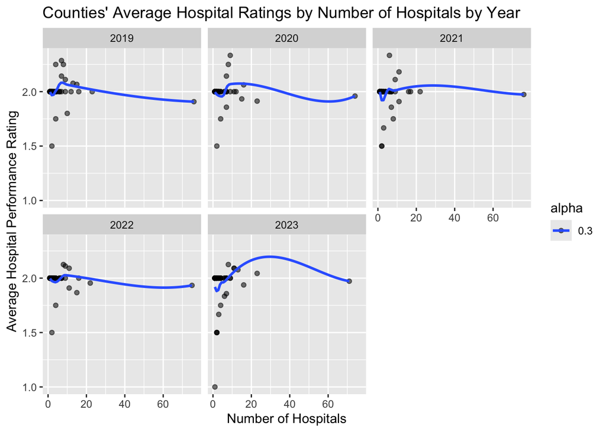

```r
# avg_rating vs n hospitals
counties %>%
  ggplot(aes(x = n, y = perf_rate_avg, alpha = 0.3)) +
  geom_point() +
  facet_wrap(vars(Year)) +
  geom_smooth(se = FALSE) +
  labs(title = "Counties' Average Hospital Ratings by Number of Hospitals by Year",
       x = "Number of Hospitals",
       y = "Average Hospital Performance Rating")
```

Next, I created 2 plots to examine whether the statewide number of elective surgeries differed by year, and whether the statewide sepsis rates differed by year. In addition to visualizing a general trend over time, I wanted to understand if the COVID-19 pandemic in 2020 had any effect on either of these metrics. In both plots, the medians and variances appear relatively equal to each other across all 5 years. There may be a slight decrease in the median and variance of Elective Surgical Discharges from 2019-2020, which appears to hold steady for the remaining years following 2020. Additionally, there appears to be increased variance in risk-adjusted postoperative sepsis rates for 2019, 2021, and 2023; there are far outliers in each of these years. Overall, these results suggest that the statewide number of elective surgeries and the statewide sepsis rates do not differ significantly by year.

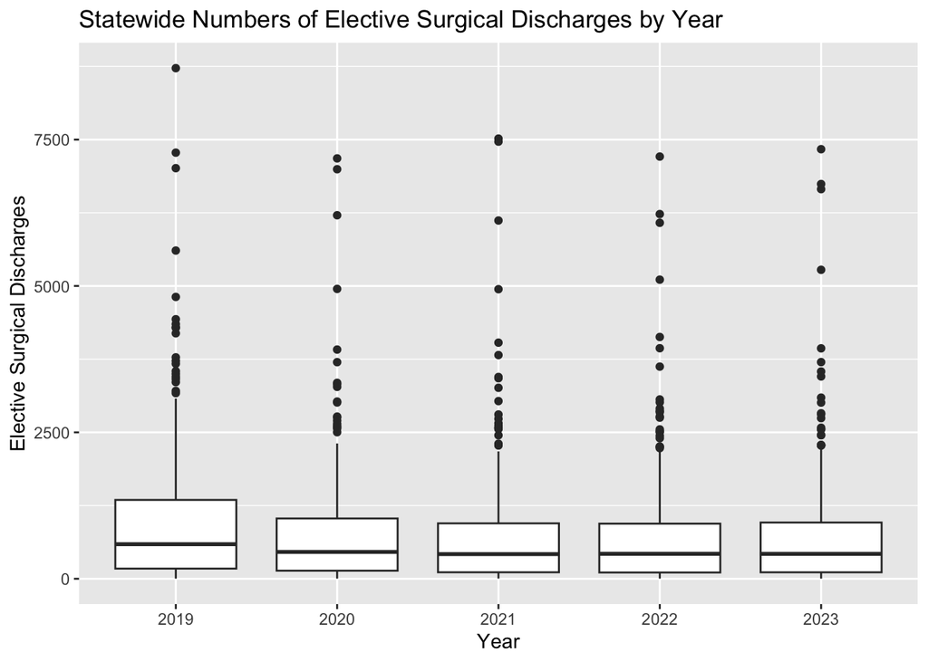

```r
# n elective surgeries by year
sepsis_rates %>%
  group_by(Year) %>%
  ggplot(aes(x = factor(Year), y = `Elective Surgical Discharges`)) +
  geom_boxplot() +
  labs(title = "Statewide Numbers of Elective Surgical Discharges by Year",
       x = "Year")
```

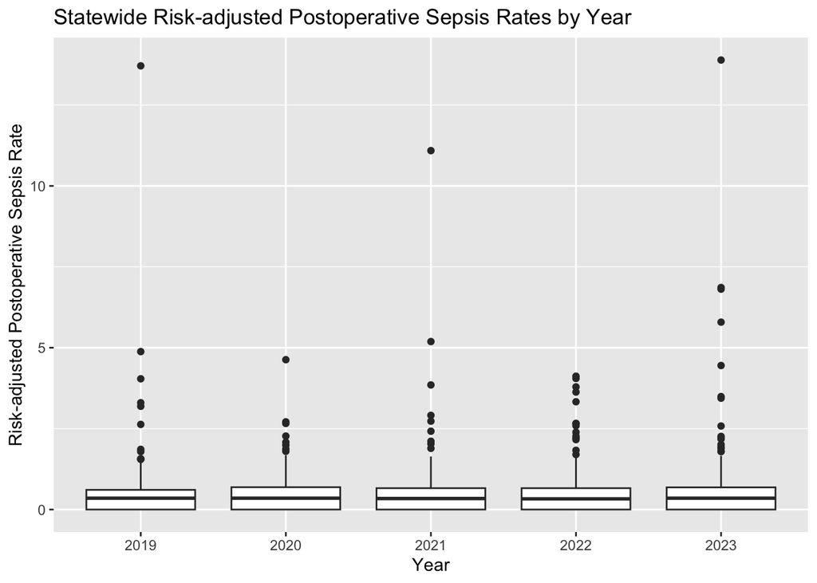

```r
# overall sepsis rate by year
sepsis_rates %>%
  group_by(Year) %>%
  ggplot(aes(x = factor(Year), y = `Risk-adjusted Postoperative Sepsis Rate`)) +
  geom_boxplot() +
  labs(title = "Statewide Risk-adjusted Postoperative Sepsis Rates by Year",
       x = "Year")
```

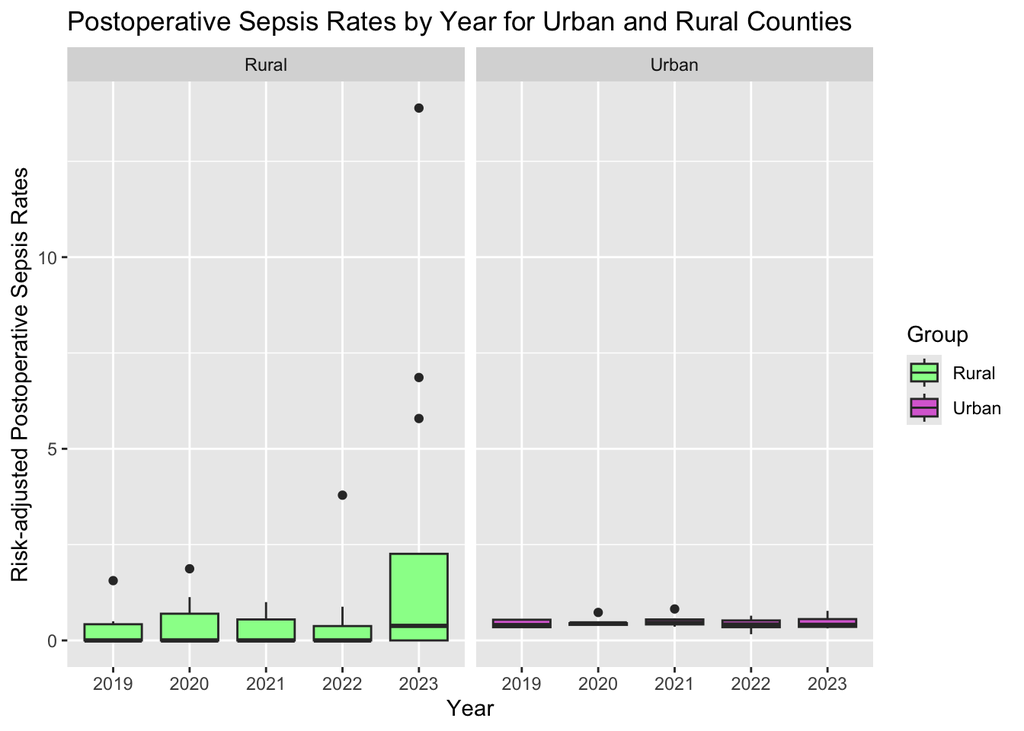

```r
# join avg_sepsis_rates to top_hospitals
top_hospitals <- left_join(top_hospitals, avg_sepsis_rates,
                           by = c("Year", "County"))

# join avg_sepsis_rates to bottom_hospitals
bottom_hospitals <- left_join(bottom_hospitals, avg_sepsis_rates,
                              by = c("Year", "County"))

# boxplots of sepsis rate by year for top and bottom counties
top_hospitals$Group <- "Urban"
bottom_hospitals$Group <- "Rural"
top_n_bottom <- rbind(top_hospitals, bottom_hospitals)

ggplot(top_n_bottom, aes(x = factor(Year), y = sepsis_avg, fill = Group)) +
  geom_boxplot() +
  facet_wrap(~ Group) +
  scale_fill_manual(values = c("palegreen", "orchid")) +
  labs(title = "Postoperative Sepsis Rates by Year for Urban and Rural Counties",
       x = "Year",
       y = "Risk-adjusted Postoperative Sepsis Rates")
```

Lastly, I wanted to visualize this data geographically. I created two sets of maps to display all the individual hospitals. The first set of maps is colored by the risk-adjusted postoperative sepsis rates. In this map, there are visible clusters where the postoperative sepsis rate was very low, however there are some isolated (and likely rural) locations where the postoperative sepsis rate is very high, particularly in the 2019 and 2023 maps. These years also stood out as having extreme outliers in the statewide postoperative sepsis rate vs year plot shown earlier. This may suggest that although rural hospitals overall do not differ in outcomes compared to urban hospitals, these counties may be more susceptible to extreme cases.

[figure not shown]

```r
# map of hospitals colored with sepsis rate
us_map <- map_data("state", region = "california")
ggplot() +
  geom_polygon(data = us_map, aes(x = long, y = lat, group = group),
               color = "white") +
  geom_point(data = sepsis_rates %>% group_by(Year),
             aes(x = Longitude, y = Latitude,
                 color = `Risk-adjusted Postoperative Sepsis Rate`)) +
  facet_wrap(vars(Year)) +
  scale_color_gradient(low = "skyblue", high = "salmon") +
  labs(title = "Map of Hospitals' Risk-adjusted Postoperative Sepsis Rates by Year",
       x = "Latitude",
       y = "Longitude") +
  guides(fill = guide_colourbar(direction = "horizontal")) +
  theme(legend.position = "bottom",
                axis.text.x = element_blank(), axis.ticks.x = element_blank(),
                axis.text.y = element_blank(), axis.ticks.y = element_blank())
```

The second set of maps is colored by the risk-adjusted performance rating. This map shows mostly “Average” ratings statewide, as expected. The lower or higher rated hospitals appear both in urban and rural environments, with no consistent patterns.

[figure not shown]

```r
# map of hospitals colored with performance rating
ggplot() +
  geom_polygon(data = us_map, aes(x = long, y = lat, group = group),
               color = "white") +
  geom_point(data = sepsis_rates %>% group_by(Year),
             aes(x = Longitude, y = Latitude,
                 color = `perf_score`)) +
  facet_wrap(vars(Year)) +
  scale_color_gradient(high = "skyblue", low = "salmon") +
  labs(title = "Map of Hospitals' Risk-adjusted Postoperative Rating by Year",
       x = "Latitude", y = "Longitude",
       color = "Risk-adjusted Postoperative Rating") +
  guides(fill = guide_colourbar(direction = "horizontal")) +
  theme(legend.position = "bottom",
                axis.text.x = element_blank(), axis.ticks.x = element_blank(),
                axis.text.y = element_blank(), axis.ticks.y = element_blank())
```

**Conclusion**

Overall, these results suggest that there is no significant change in risk-adjusted postoperative sepsis rates from 2019-2023 in California hospital, and this result does not change significantly when the data is stratified based on urban vs rural regions, although rural hospitals may be more susceptible to extreme cases. Additionally, the COVID-19 pandemic did not have an appreciable effect on this. This data suggests that, solely by the Postoperative Sepsis Indicator, quality of inpatient hospital care is roughly equivalent across California from 2019-2023.

This time span is relatively small; the practices to reduce postoperative sepsis rates have been established over decades rather than individual years. One could further explore this question by investigating it over decades. Additionally, one could expand to compare data from other states in the US.